# ANOVA II

Ane Kleiven

2025-03-05

# 1 Ex-1: Data from the NSR education test, revisited

See exercises week 4, the Tukey’s test was performed in the last task.

# 2 Ex-2: Yield of Barley

Parametrization:

- Sum to zero contraint:

Sum of all levels of i in factor a must be zero Sum of all levelse of j in factor b must be zero Sum of all levels of i in the interaction ab, sum of all levels of j in the interaction term)

- The model:

yijk = mu + ai + bj + (ab)ij + eijk

Where y is the response variable yield of barley Mu is the grand mean ai is the effect of the ith level of factor a (Variety) bj is the effect of the jth level of factor b (Soil) (ab)ij is the interaction effect between the ith level of factor a and the jth level of factor b eijk is the random error term with mean zero and variance sigma squared

### Fit the model in R

```r
# load data
library(mixlm)
library(car)
library(effects)
library(BIAS.data)

data(Barley)

# fit the model

mod1 <- lm(Yield ~ Variety * Soil, data = Barley, contrasts="contr.sum")
summod1 <- summary(mod1, cor=FALSE)
print(summod1)
```

```
##
## Call:
## lm(formula = Yield ~ Variety * Soil, data = Barley, contrasts = "contr.sum")
##
## Residuals:
##     Min      1Q  Median      3Q     Max
## -88.469 -44.322   5.009  35.219 106.913
##
## Coefficients:
##              Estimate Std. Error t value Pr(>|t|)
## (Intercept)    385.17      19.30  19.955   <2e-16 ***
## Variety         56.96      27.30   2.087   0.0462 *
## Soil           -35.71      27.30  -1.308   0.2015
## Variety:Soil   -73.62      38.60  -1.907   0.0668 .
## ---
## Signif. codes:  0 '***' 0.001 '**' 0.01 '*' 0.05 '.' 0.1 ' ' 1
##
## s: 54.6 on 28 degrees of freedom
## Multiple R-squared: 0.4022,
## Adjusted R-squared: 0.3382
## F-statistic:  6.28 on 3 and 28 DF,  p-value: 0.002142
```

```r
anova(mod1)
```

```
## Analysis of Variance Table
##
## Response: Yield
##              Df Sum Sq Mean Sq F value    Pr(>F)
## Variety       1   3247    3247  1.0893 0.3055521
## Soil          1  42071   42071 14.1146 0.0008031 ***
## Variety:Soil  1  10841   10841  3.6370 0.0668166 .
## Residuals    28  83459    2981
## ---
## Signif. codes:  0 '***' 0.001 '**' 0.01 '*' 0.05 '.' 0.1 ' ' 1
```

### Estimate model parameters

**Model parameter:**

- mu: 385.17
- ai: 56.96
- bj: -35.71
- (ab)ij: -73.62
- sigma squared (unexplained variability) = MSE = 2981 (SSE/df)

### Interaction plot

```r
# plot(allEffects(mod1, confidence.level = 0.95))
```

### Perform a hypothesis test of the interaction effect

H0: (ab)ij = 0 H1: some level of (ab)ij != 0

Significance level: 0.05

```r
anova(mod1)
```

```
## Analysis of Variance Table
##
## Response: Yield
##              Df Sum Sq Mean Sq F value    Pr(>F)
## Variety       1   3247    3247  1.0893 0.3055521
## Soil          1  42071   42071 14.1146 0.0008031 ***
## Variety:Soil  1  10841   10841  3.6370 0.0668166 .
## Residuals    28  83459    2981
## ---
## Signif. codes:  0 '***' 0.001 '**' 0.01 '*' 0.05 '.' 0.1 ' ' 1
```

We can see from the anova table that the p-value for the interaction term is 0.0668. Since this is higher than the significance level, we fail to reject the null hypothesis. We can not say that there is a significant interaction effect between the variety and soil type on the yield of barley.

### Fit a four factor model

```r
mod2 <- lm(Yield ~ Variety * Soil * Fertilizer * Site, data = Barley, contrasts="contr.sum")
anova(mod2)
```

```
## Analysis of Variance Table
##
## Response: Yield
##                              Df Sum Sq Mean Sq F value    Pr(>F)
## Variety                       1   3247    3247  4.9373 0.0410530 *
## Soil                          1  42071   42071 63.9750  5.56e-07 ***
## Fertilizer                    1   9846    9846 14.9725 0.0013585 **
## Site                          1   1073    1073  1.6323 0.2196068
## Variety:Soil                  1  10841   10841 16.4848 0.0009095 ***
## Variety:Fertilizer            1   6398    6398  9.7296 0.0066081 **
## Soil:Fertilizer               1  46396   46396 70.5525  2.93e-07 ***
## Variety:Site                  1   1073    1073  1.6320 0.2196548
## Soil:Site                     1   1405    1405  2.1361 0.1632290
## Fertilizer:Site               1    191     191  0.2901 0.5975463
## Variety:Soil:Fertilizer       1   3639    3639  5.5341 0.0317798 *
## Variety:Soil:Site             1   2671    2671  4.0612 0.0609974 .
## Variety:Fertilizer:Site       1      4       4  0.0063 0.9378245
## Soil:Fertilizer:Site          1    154     154  0.2337 0.6353262
## Variety:Soil:Fertilizer:Site  1     86      86  0.1308 0.7223569
## Residuals                    16  10522     658
## ---
## Signif. codes:  0 '***' 0.001 '**' 0.01 '*' 0.05 '.' 0.1 ' ' 1
```

```r
summary(mod2)
```

```
##
## Call:
## lm(formula = Yield ~ Variety * Soil * Fertilizer * Site, data = Barley,
##     contrasts = "contr.sum")
##
## Residuals:
##    Min     1Q Median     3Q    Max
## -39.10 -11.44   0.00  11.44  39.10
##
## Coefficients:
##                               Estimate Std. Error t value Pr(>|t|)
## (Intercept)                   343.5266    18.1331  18.945  2.2e-12 ***
## Variety                        36.6158    25.6440   1.428 0.172563
## Soil                           12.9947    25.6440   0.507 0.619252
## Fertilizer                    111.4824    25.6440   4.347 0.000499 ***
## Site                          -34.8928    25.6440  -1.361 0.192481
## Variety:Soil                   -0.9803    36.2661  -0.027 0.978770
## Variety:Fertilizer            -19.0243    36.2661  -0.525 0.607070
## Soil:Fertilizer              -107.4431    36.2661  -2.963 0.009166 **
## Variety:Site                   54.5868    36.2661   1.505 0.151764
## Soil:Site                      12.2494    36.2661   0.338 0.739933
## Fertilizer:Site                13.4130    36.2661   0.370 0.716344
## Variety:Soil:Fertilizer       -72.2000    51.2880  -1.408 0.178341
## Variety:Soil:Site             -59.9703    51.2880  -1.169 0.259415
## Variety:Fertilizer:Site        10.2413    51.2880   0.200 0.844244
## Soil:Fertilizer:Site           -4.4178    51.2880  -0.086 0.932427
## Variety:Soil:Fertilizer:Site  -26.2301    72.5322  -0.362 0.722357
## ---
## Signif. codes:  0 '***' 0.001 '**' 0.01 '*' 0.05 '.' 0.1 ' ' 1
##
## s: 25.64 on 16 degrees of freedom
## Multiple R-squared: 0.9246,
## Adjusted R-squared: 0.854
## F-statistic: 13.09 on 15 and 16 DF,  p-value: 2.946e-06
```

From the model summary, we can see that there is one significant main effect, and one significant interaction effect at 5% significance level:

1. Fertilizer main effect
2. Interaction effect between Soil and Fertilizer

However, the least squares estimator is prone to inflated variance estimates and difficulties in finding significance when the number of variables k rises compared to the number of observations N and if variables are highly correlated. Too many variables to estimate from a limited number of observations leaves few degrees of freedom to SSE, and tests with low power. Lack of significance may be an over-fitting problem. By removing some of the least significant variables, the problem is reduced, and a reduced model with significant effects may be identified.

The large difference between R2 and R2adj is also an indication of an over-fitted model.

### Reduced model with `backward()` in mixlm

```r
mod3 <- backward(mod2, alpha=0.05, full = TRUE, hierarchy = TRUE)
```

```
## Backward elimination, alpha-to-remove: 0.05
##
## Full model: Yield ~ Variety + Soil + Fertilizer + Site + Variety:Soil + Variety:Fertilizer +
##     Soil:Fertilizer + Variety:Site + Soil:Site + Fertilizer:Site +
##     Variety:Soil:Fertilizer + Variety:Soil:Site + Variety:Fertilizer:Site +
##     Soil:Fertilizer:Site + Variety:Soil:Fertilizer:Site
##
## --= Step 1 =--
## Single term deletions
##
## Model:
## Yield ~ Variety * Soil * Fertilizer * Site
##                              Df Sum of Sq   RSS    AIC F value Pr(>F)
## <none>                                    10522 217.46
## Variety:Soil:Fertilizer:Site  1    86.002 10608 215.72  0.1308 0.7224
##
##
## --= Step 2 =--
## Single term deletions
##
## Model:
## Yield ~ Variety + Soil + Fertilizer + Site + Variety:Soil + Variety:Fertilizer +
##     Soil:Fertilizer + Variety:Site + Soil:Site + Fertilizer:Site +
##     Variety:Soil:Fertilizer + Variety:Soil:Site + Variety:Fertilizer:Site +
##     Soil:Fertilizer:Site
##                         Df Sum of Sq   RSS    AIC F value  Pr(>F)
## <none>                               10608 215.72
## Variety:Soil:Fertilizer  1    3639.3 14247 223.15  5.8323 0.02728 *
## Variety:Soil:Site        1    2670.7 13279 220.90  4.2801 0.05412 .
## Variety:Fertilizer:Site  1       4.1 10612 213.73  0.0066 0.93612
## Soil:Fertilizer:Site     1     153.7 10762 214.18  0.2463 0.62604
## ---
## Signif. codes:  0 '***' 0.001 '**' 0.01 '*' 0.05 '.' 0.1 ' ' 1
##
##
## --= Step 3 =--
## Single term deletions
##
## Model:
## Yield ~ Variety + Soil + Fertilizer + Site + Variety:Soil + Variety:Fertilizer +
```

[output cut: 25 more lines]

```
##
##
## --= Step 5 =--
## Single term deletions
##
## Model:
## Yield ~ Variety + Soil + Fertilizer + Site + Variety:Soil + Variety:Fertilizer +
##     Soil:Fertilizer + Variety:Site + Soil:Site + Variety:Soil:Fertilizer +
##     Variety:Soil:Site
##                         Df Sum of Sq   RSS    AIC F value  Pr(>F)
## <none>                               10956 210.75
## Variety:Soil:Fertilizer  1    3639.3 14596 217.93  6.6432 0.01798 *
## Variety:Soil:Site        1    2670.7 13627 215.73  4.8752 0.03909 *
## ---
## Signif. codes:  0 '***' 0.001 '**' 0.01 '*' 0.05 '.' 0.1 ' ' 1
```

```r
anova(mod3)
```

```
## Analysis of Variance Table
##
## Response: Yield
##                         Df Sum Sq Mean Sq F value    Pr(>F)
## Variety                  1   3247    3247  5.9269 0.0244049 *
## Soil                     1  42071   42071 76.7965 2.773e-08 ***
## Fertilizer               1   9846    9846 17.9732 0.0004019 ***
## Site                     1   1073    1073  1.9595 0.1768893
## Variety:Soil             1  10841   10841 19.7886 0.0002467 ***
## Variety:Fertilizer       1   6398    6398 11.6796 0.0027287 **
## Soil:Fertilizer          1  46396   46396 84.6922 1.255e-08 ***
## Variety:Site             1   1073    1073  1.9591 0.1769344
## Soil:Site                1   1405    1405  2.5642 0.1249852
## Variety:Soil:Fertilizer  1   3639    3639  6.6432 0.0179818 *
## Variety:Soil:Site        1   2671    2671  4.8752 0.0390875 *
## Residuals               20  10956     548
## ---
## Signif. codes:  0 '***' 0.001 '**' 0.01 '*' 0.05 '.' 0.1 ' ' 1
```

The reduced model includes:

- The main effects of all four factors (three of four significant)
- Five 2-order interactions (three significant)
- Two three order interactions (significant)

The principle of marginality says that one should keep all higher order effects if the interactions are significant, therefore some main effects and 2-order interactions are included in the reduced model.

### Model check of the reduced model (residual analysis)

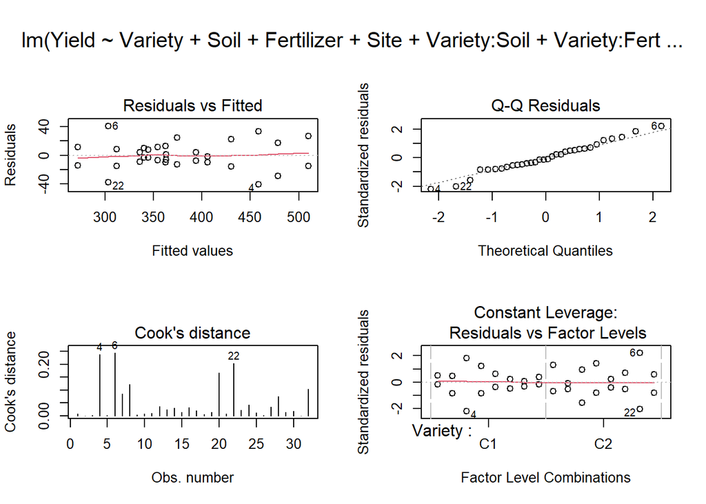

```r
par(oma =c(0,0,3,0), mfrow = c(2,2))
plot(mod3, which = c(1,2,4,5), add.smooth = TRUE)
```

```r
#eff <- allEffects(mod3, confidence.level = 0.95)
#plot(eff[2])
```

# 3 Ex-3: Indicator variable (ANCOVA model)

Fit the model

Miles Per Gallon (mpg) = response variable Weight (wt) = predictor variable Number of cylinders (cyl) = predictor variable Am = indicator variable for automatic transmission (1 = automatic, 0 = manual)

yi = b0 + b1x1 + b2x2 + b3x3 + b4x2*x3 + ei

Where:

- i = 1,2,3,…,32 is the car number
- Yi is the `miles per gallon` of the car and is the response variable
- X1 is the `Number of cylinders` of the car and is the second predictor variable
- X2 is the `Weight` of the car and is the first predictor variable
- X3 is the `Automatic transmission` of the car and is the third predictor variable
- εi is the error term for car number i, i.e. the difference between observed and expected miles per gallon for car number i.

Model assumptions:

- There is a linear relationship between x and y
- The error terms are normally distributed
- The error terms have a constant variance σ2 for all cars
- The error terms are independent

```r
mtcars$am <- factor(mtcars$am)

cars <- lm(mpg ~ cyl + wt * am, data=mtcars, contrasts= list(am = "contr.sum"))
summary(cars)
```

```
##
## Call:
## lm(formula = mpg ~ cyl + wt * am, data = mtcars, contrasts = list(am = "contr.sum"))
##
## Residuals:
##     Min      1Q  Median      3Q     Max
## -3.4621 -1.4913 -0.7879  1.3959  5.3499
##
## Coefficients:
##             Estimate Std. Error t value Pr(>|t|)
## (Intercept)  40.2523     1.9170  20.997  < 2e-16 ***
## cyl          -1.1814     0.3803  -3.106  0.00442 **
## wt           -4.4676     0.8943  -4.996 3.08e-05 ***
## am(0)        -5.9693     1.9227  -3.105  0.00444 **
## wt:am(0)      2.0987     0.6558   3.200  0.00350 **
## ---
## Signif. codes:  0 '***' 0.001 '**' 0.01 '*' 0.05 '.' 0.1 ' ' 1
##
## s: 2.265 on 27 degrees of freedom
## Multiple R-squared: 0.877,
## Adjusted R-squared: 0.8588
## F-statistic: 48.13 on 4 and 27 DF,  p-value: 6.643e-12
```

For the automatic transmission (am = x3 = 1):

y hat = 40.25 -1.18x1 -4.47x2 -5.97 + 2.10x2 = 34.28 - 1.18x1 - 2.37x2

For the manual transmission (am = x3 = -1):

y hat = 40.25 -1.18x1 -4.47x2 + 5.97 - 2.10x2 = 46.22 - 1.18x1 - 6.57x2

We observe that the negative effect of weight on miles per gallon is larger for manual transmission cars than for automatic transmission cars.